*Humans are changing Planet Earth at a rapid pace. I am a scientist trying to understand and communicate the ecological consequences of global change.*

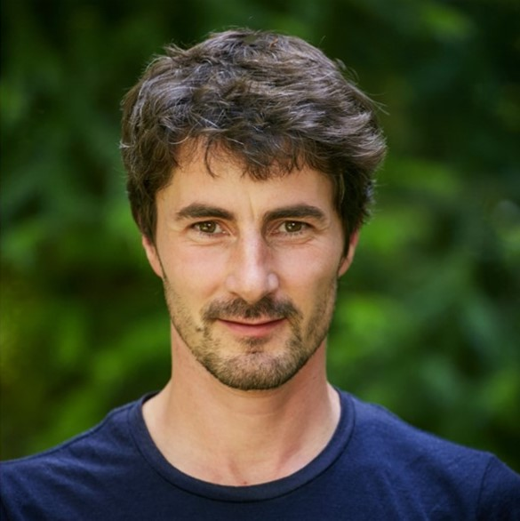

# Johannes Ingrisch

[twitter](https://twitter.com/JohnnyIngrisch) [Orcid](https://orcid.org/0000-0002-8461-8689) CV

I am an ecologist by training and have been studying the effects of climate change on ecosystems for more than 10 years. My main research interest is to understand the resilience of plants, soils, and ecosystems to extreme climatic events like drought. I do so, by combining conceptual frameworks of resilience, field experiments, and data science.

I am interested in applying data science and data visualisation to gain and communicate new insights.

## Education

Master Data Science | University of Innsbruck | 2022 - ongoing

PhD | University of Innsbruck | 2012 - 2018

MSc Geoecology | University of Bayreuth | 2009 - 2011

BSc Geoecology | University of Bayreuth | 2005 - 2008

## Experience

Postdoc | University of Innsbruck | 2018 - ongoing

Postdoc | University of Freiburg | 2019 - 2021

Visiting Scientist | University of Arizona | 2019

Research Assistant | University of Vienna | 2017

Research Campaign in Tibet | TiP AEG cluster | 2010

Erasmus exchange semester | Sweden | 2009